# CF: A *Stochastic* Car-Following Package

Paul J. Ossenbruggen

2018-01-25

## Overview

The CF package is designed for college students studying transportation engineering and for transportation professionals and researchers interested in understanding the complex relationships associated with freeway performance and traffic breakdown. Newton’s Laws of dynamics, fundamentals of trafic flow theory (TFT) and probabilistic modeling are used in this package. Observational data, collected with loop detectors, radar and by other means, are often prohibitedly expensive to obtain. Thus, decision-makers are often faced with challenging problems owing the lack of quality data. Our aim to overcome these difficulties by providing tools derived from classical theory, stochastic modeling and sound judgement.

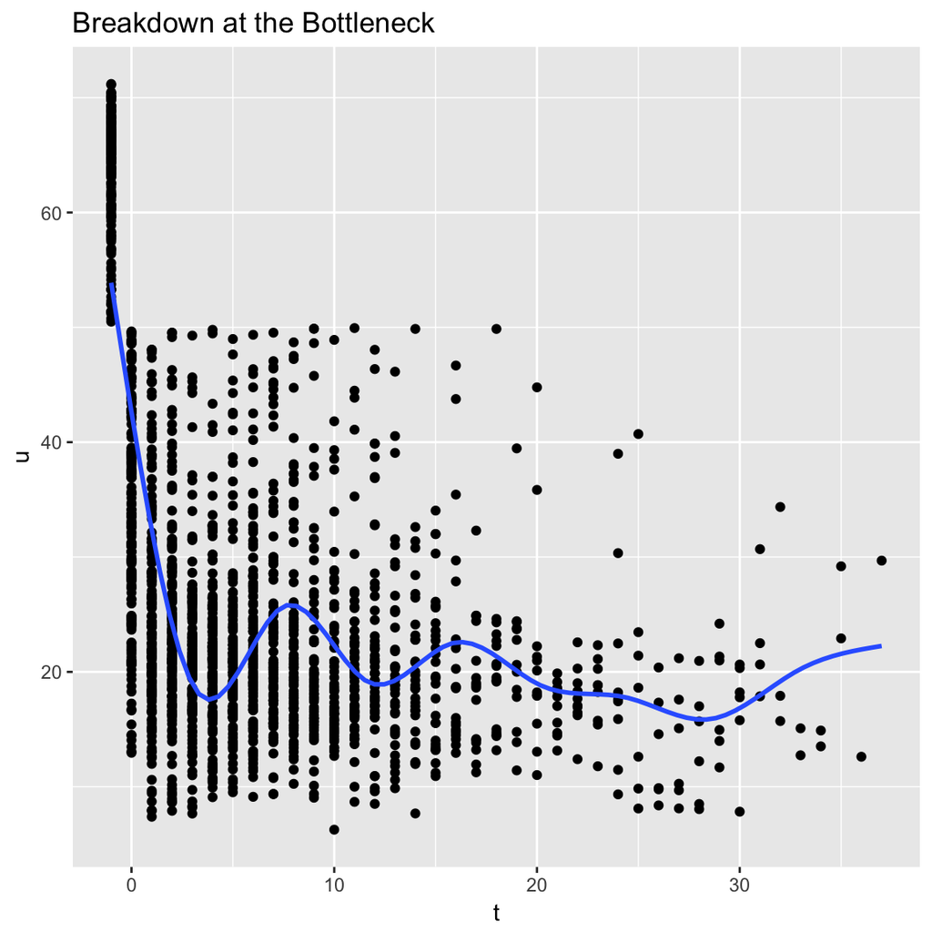

```r
speedplot()
```

Traffic data are extremely noisy or *volatile*. By ignoring this volatility, theorists have been able to elequently describe traffic behavior by using deterministic models. Of course, there is the fear that important information about the complex nature of traffic behavior is lost. By using deterministic and stochastic models with the aid of high-speed computing, we attempt to simulate reality. That includes mimicing human and vehicle dynamics behavior as realistically as possible. For example, a varying acceleration model is used in place of constant velocity modeling. This model depicts vehicles accelerating and decelerating instanteously. The time-varying acceleration $\alpha(t)$ function overcomes this difficulty:

$\alpha(t) = a - b t$

where $t$ denotes time. The constants $a$ and $b$ are estimated by using boundary conditions. Knowing $\alpha(t)$, speed $u(t) and distance $x(t)$ can be forecast. Forecasts from the $\alpha(t)$ and the exponential model of speed, $u(t) = exp(-\lambda t)$, prove effective in modeling *traffic breakdown*.

## Animation and Stochastic Processes

A most effective tool for understanding various characteristics of traffic performance is the use of time-space $t-x$ trajectories. See the animation entitled *Vehicles entering a Bottleneck* below. It shows the trajectories of three vehicles. The trajectories were derived from the time-varying acceleration $\alpha(t)$ model exclusively.

The reader cannot help notice that this vignette contains several panels including an input panel to the **zipper()** function that produces the animation as well as an output panel with some details of the different trajectories. The other panels contain the names of the R packages and output comments. Readers interested in traffic engineering can disregard these panels.

Before discussing the examples, we will clearly disinguish difference between *animation* and a *stochastic process.* The function produces an *animation* as shown in the $t-x$ trajectory. Two lanes of traffic merge into one line forcing the drivers to merge.

```
    1. What is a bottleneck?

    2. What are the top speeds of vehicles 2 and 3 in passing vehicle 1?

    3. Are the drivers of these vehicles driving safely?

    4. Is this animation a reasonable description of reality?
```

*Car-following* models simulate traffic behavior much differently. After the merge, the driver in lane 2 becomes a *lead* vehicle. The *lead* vehicle driver affects all drivers of lanes 1 and 2, the *following* vehicles. To avoid a crash under the conditions described in the preceding paragraph, the driver in lane 1 will decelerate, which in turn will influence all vehicles following him or her especially when the traffic density is relatively large.

The animation depicted below is an idealistic description of a *zipper* merge. To achieve a zipper merge, all drivers must be highly disciplined. Not only must they maintain the same exact speed and most importantly, must be perfectly aligned when merging. A situation that analogous to closing a zipper. When the two halves of a zipper are joined together, it becomes securely fastened together because the zipper teeth are precisely aligned on zipper tape. Zippers work well regardless of how fast or slow the zipper is fastened together. Roadway zipper merges can be observed in the field but only at low speed.

The **zipper()** function calls the two **R** packages as shown.

```r
library(animation)
library(dplyr)
```

```
##   lane int.spd min.max.speed time   a   b
## 1    1      25        25.000  0.0 0.0 0.0
## 2    2      25        32.500  5.0 3.0 0.6
## 3    2      30        35.208  4.2 2.5 0.6
```

```
## geom_path: Each group consists of only one observation. Do you need to
## adjust the group aesthetic?
```

[figure not shown]

```r
library(gganimate)
library(gapminder)
library(ggplot2)
library(tidyverse)
tstart <- 0
tend   <- 10
ustart1 <- 25
uend1   <- 25
xstart1 <- 0
xend1   <- 250
ustart2 <- 25
uend2   <- 25
xstart2 <- 0
xend2   <- 300
ustart3 <- 30
uend3   <- 25
xstart3 <- -50
xend3   <- 275
zipper(tstart,tend,ustart1,uend1,xstart1,xend1,ustart1,uend2,xstart2,xend2,ustart3,uend3,xstart3,xend3)
```

The **brownian.motion** function is a *stochastic model*. The *animation* shows 10 small particles, grains of pollen suspeneded in water. The particles are initially located at the point $(x = 0, y = 0)$, will randomly drift from this position. Clearly, the process is time-dependent process. The particles become more dispersed over time.

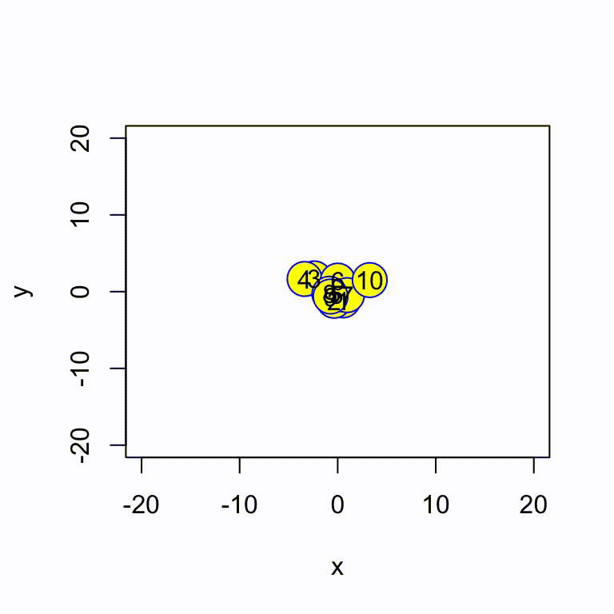

The following trajectory is generated with a Brownian motion model of speed of the form: $u_t = \bar{u} + \sigma W$ where $u_t$ is the speed at time $t$, $\bar{u}$ is the average speed of vehicle at which the driver is attempting to maintain, $\sigma$ is the standard deviation of $u_t$, and $W_t$ is Brownian motion. Brownian motion model is defined as $W_t \sim \sqrt{\Delta t} Z$ where $Z \sim N(0,1)$, a standard normal probability distribution and $\Delta t$ is the time step.

```
## geom_path: Each group consists of only one observation. Do you need to
## adjust the group aesthetic?
```

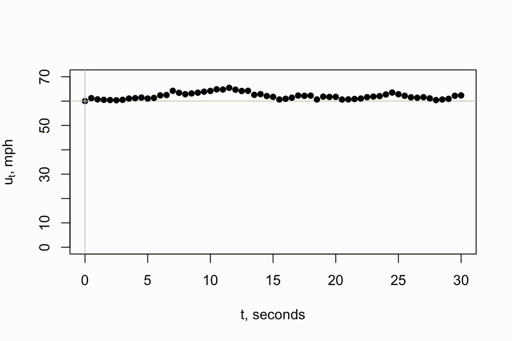

The following three examples give a glimpse of the data analyses that can be performed with output from the package.

## 1: Ring-Road Congestion

Now, we will take advantage of classical dynamics, deterministic and stochastic models and computer simulation to explain traffic behavior observed in the field.

Here, drivers attempt to maintain an average speed $u$ of 10 miles per hour (mph) on a ring road. We investigate the trajectories of eleven vehicles. The traffic density $k$ is assumed to be 55 vehicles per mile (vpm), thus we are simulating congested traffic . The $t-x$ trajectory shows the drivers, whose vehicle are evenly spaced initially, are unable to maintain a constant headway after a few seconds. The vehicles interact and form clusters (moving queues) owing to their inability to maintain a constant speed of 10 mph. The traffic flow for this simulation is estimated to be 547 vehicle per hour. This prediction matches the conditions observed in a full-scale experiment on a ring road.

Input to the **rrtrials** function for analyzing a ring road:

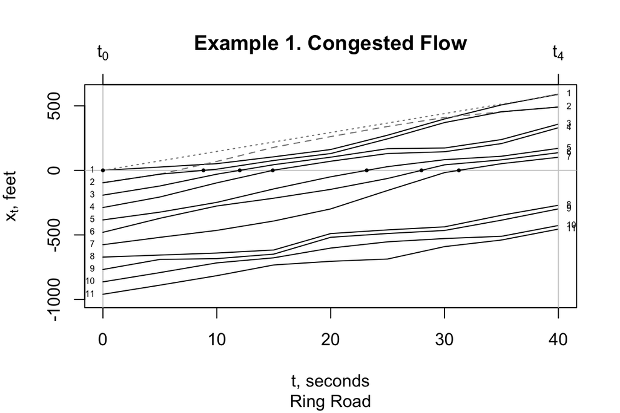

```r
set.seed(124)
output <- rrtrials(10, 3, 55, 40, 5, 14, 10, c(0, 40), c(-1000, 600))
title("Example 1. Congested Flow", "Ring Road")
```

The “output” from the **rrtrials** function produces a $t-x$ trajectory and data for level-of-service estimation.

[output not shown]

## 2. Bottleneck Congestion.

Input to the **run** function produces a collection of data frames, which we call the “cflist.” The information from these data frames can be inspected to give a detailed look at the interaction between the lead and flowwing vehicles during a traffic breakdown.

```r
set.seed(123)
nveh <- 10
ulead <- 63
ulead.sd <- 10
ubrkdown <- 34
ubrkdown.sd <- 0.1
k <- 55
k.sd <- 5
d <- 15
leff <- 14
xlim <- c(0,60)
ylim <- c(-2000, 4000)
cflist <- run(nveh, ulead, ulead.sd, ubrkdown, ubrkdown.sd, k, k.sd, d, leff, xlim, ylim)
```

```
##          t0 t1 t2        t3
## t    0.0000 NA NA  1.453568
## u   92.4000 NA NA 70.596486
## x -117.7532 NA NA  0.000000
## h  176.9496 NA NA 81.387555
```

```
## [1] "Sight line and finding t2: t2 is a response time where the following vehicle driver"
## [1] "sees the location and speed of the lead vehicle and responds accordingly."
## [1] -117.7532249 -294.7027999   92.4000000   92.4000000   -0.1851628
## [6]   14.0000000
```

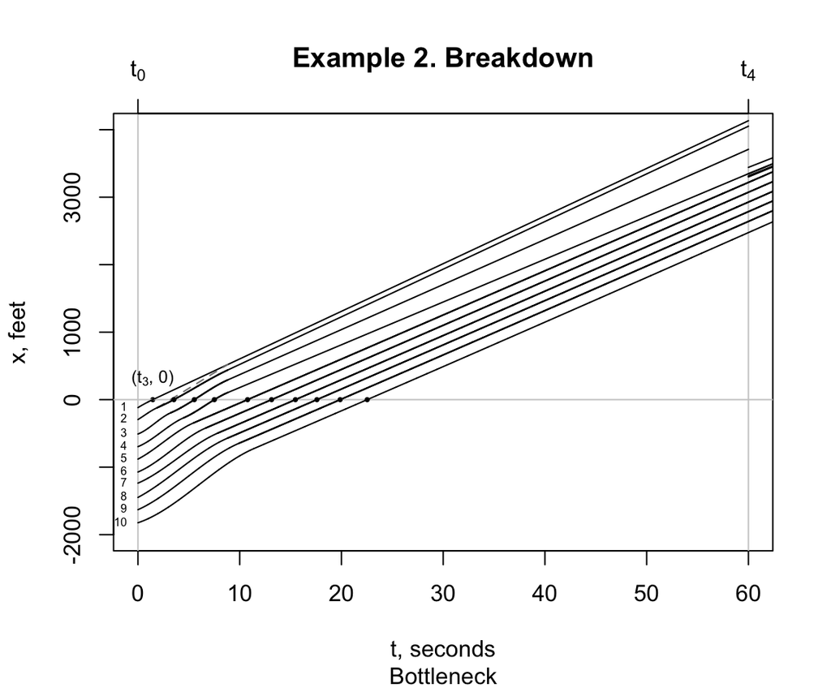

```
##          t0 t1 t2        t3
## t    0.0000 NA NA  1.458135
## u   92.4000 NA NA 70.527974
## x -118.0685 NA NA  0.000000
## h  201.2069 NA NA 81.322157
```

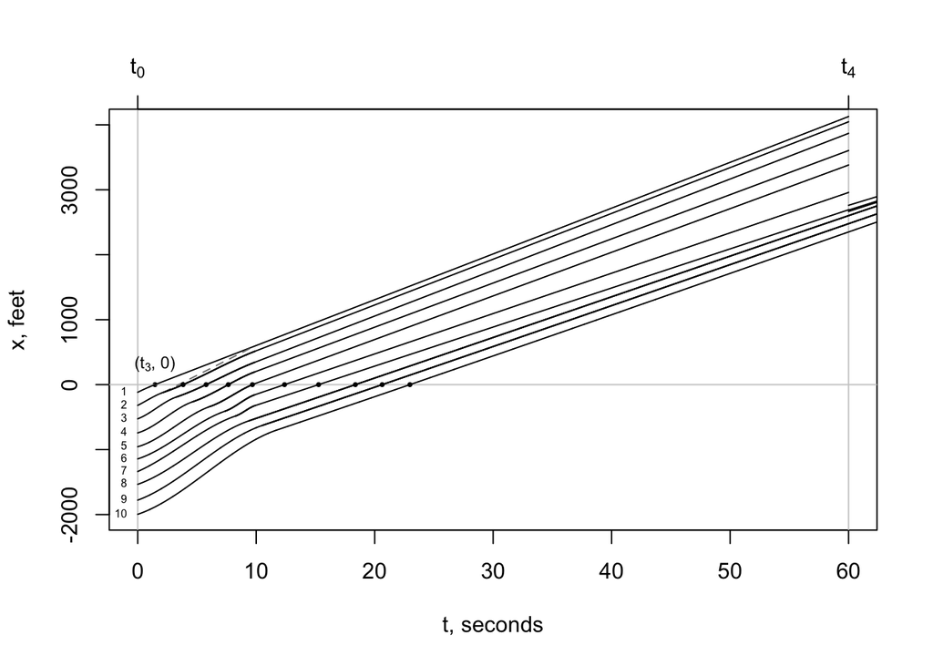

```
## [1] "Sight line and finding t2: t2 is a response time where the following vehicle driver"
## [1] "sees the location and speed of the lead vehicle and responds accordingly."
## [1] -118.0684754 -319.2753263   92.4000000   92.4000000   -0.1852487
## [6]   14.0000000
```

Traffic Characteristics

| Vehicle | Speed at t0 | Speed at t3 | Density at t1 |
| --- | --- | --- | --- |
| 1 | 63 | 48 | 52 |
| 2 | 68 | 48 | 51 |
| 3 | 53 | 46 | 49 |
| 4 | 50 | 46 | 50 |
| 5 | 58 | 42 | 56 |
| 6 | 81 | 41 | 54 |
| 7 | 64 | 40 | 53 |
| 8 | 66 | 39 | 43 |
| 9 | 61 | 38 | 48 |
| 10 | 68 | 38 | 54 |

```r
title("Example 2. Breakdown", "Bottleneck")
```

The above table shows the input to the **run** function are stochastic. The level-of-service estimates at the $x = 0$ are:

| Mean headway $\bar{h}$ | Headway standard deviation $\hat{\sigma}_h$ | Estimated flow $\bar{q}$ |
| --- | --- | --- |
| 6.7 seconds | 20 seconds | 540 vehicles per hour (vph) |

## 3. Explaining Breakdown.

Inspection of the figure shows the simulation range from $t_0$ to $t_4$. Time $t_3$ is the time the lead vehicle reaches the bottleneck $x_0$. Times $t_1$ are the times the following vehicle drivers begin to decelerate. These times depend on several factors, including lead and following vehicle speeds, vehicle spacing and driver response or driver sightlines, shown by broken lines connecting the points $(t_1, x_1)$ and $(t_2, x_2)$. Times $t_5$ are times the following vehicles reach the bottleneck at $x = 0$. The time headways are critical in estimating the traffic flow, reported above, and to estimate delay (not reported in this vignette).

```
##          t0 t1 t2        t3
## t    0.0000 NA NA  2.566906
## u   92.4000 NA NA 53.896405
## x -183.3461 NA NA  0.000000
## h  227.2059 NA NA 65.446568
```

```
## [1] "Sight line and finding t2: t2 is a response time where the following vehicle driver"
## [1] "sees the location and speed of the lead vehicle and responds accordingly."
## [1] -183.346075 -410.551946   92.400000   92.400000   -0.210005   14.000000
```

```
##      nveh ulead ulead.sd ubrkdown ubrkdown.sd  k k.sd  d leff
## [1,]    3    63       10       34         0.1 55    5 15   14
```

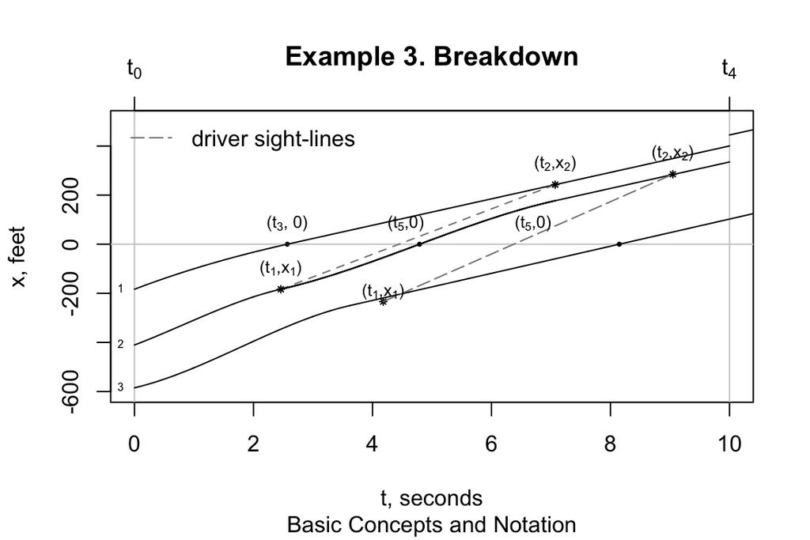

## CF Package Potential.

The potential of the **CF** package will be addressed with a question: What have we learned about traffic performance?

## Next Steps.

The potential of **CF** package has been introduced in this vignette. There is no question that traffic is complex problem. To deal with myriad problems and issues associated with traffic congestion, a better understanding of the root causes of conditions that lead to conditions must be understood. This is proving to be a daunting task. Hopefully, this vignette shows that a deeper understanding can be achieved.

Second, this package is open to the public, https://github.com/PJOssenbruggen/CF. In other words, I am inviting people to share their experiences with the package with me. GitHub promotes this activity, https://github.com/explore.